# Practical Machine Learning - Course Project Writeup

## Data Loading & Preprocessing

First of all we need to load the training and testing datasets from the csv-files. The assumption is that the files reside in the current working directory. We treat division by zero errors as “NA”.

```r
library(caret)
library(randomForest)
library(rattle)
library(rpart)
set.seed(32343)

rawTrainingData <- read.csv("pml-training.csv", header=T, na.strings=c("NA", "#DIV/0!"));
rawFinalTestingData <-read.csv("pml-testing.csv", header=T, na.string=c("NA", "#DIV/0!"));
```

We reduce the number of 160 variables to the relevant ones for the problem. We remove user, timestamp and window related variables (cols 1 - 7).

```r
trainingData <- rawTrainingData[, -c(1:7)]
finalTestingData <- rawFinalTestingData[, -c(1:7)]
```

Next we eliminate all variables that contain `NA` values.

```r
trainingHasNa <- apply(trainingData, 2, function(x) { any(is.na(x)) } )
trainingData <- trainingData[, !trainingHasNa]

testingHasNa <- apply(finalTestingData, 2, function(x) { any(is.na(x)) } )
finalTestingData <- finalTestingData[, !testingHasNa]
```

## Data Partition

Partition the training data set into independent training and testing data sets using 75 % for the training data set and 25 % for the testing data partition used for cross-validation.

```r
partTrain <- createDataPartition(y = trainingData$classe, p=0.75, list = FALSE)

trainingDataPartition <- trainingData[partTrain, ]
testingDataPartition <- trainingData[-partTrain, ]
```

## Classification Tree Model

### Training

Traing the model on the training data using a classification tree model.

```r
rpFit <- train(classe ~ ., method = "rpart" , data = trainingDataPartition)
```

Plot the model using rattle fancy plot.

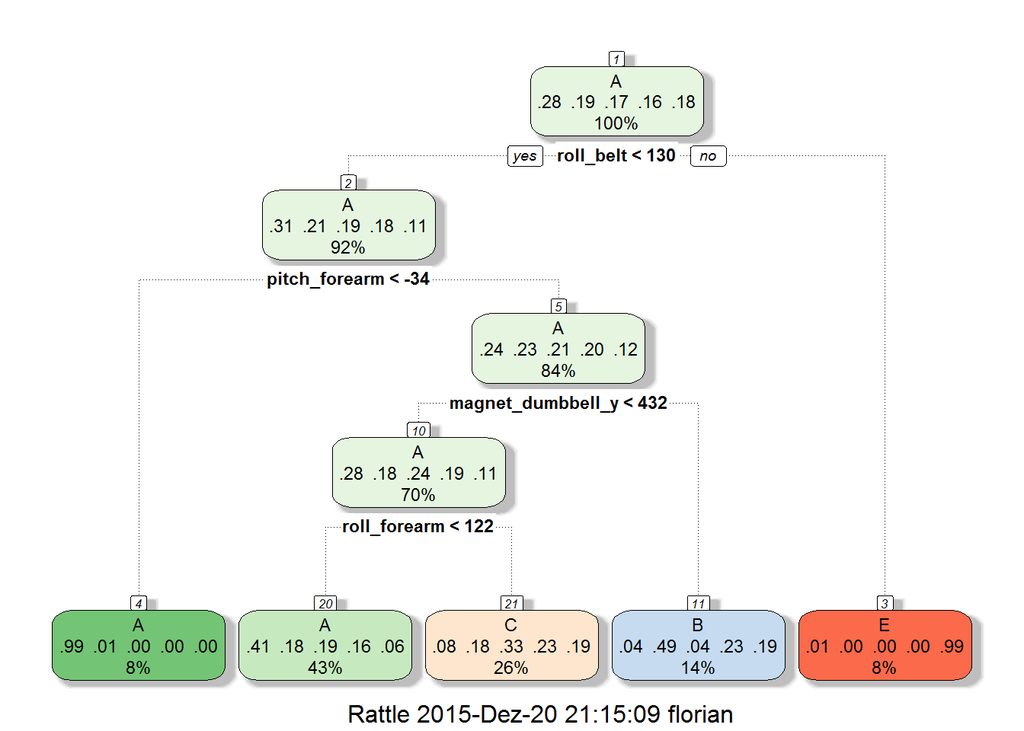

```r
fancyRpartPlot(rpFit$finalModel)
```

### Prediction

Predict using the test data partition for cross validation.

```r
rpPred <- predict(rpFit, newdata = testingDataPartition)
```

### Cross Validation

The model yields the following confusion matrix.

```r
rpPredConfMatrix <- confusionMatrix(rpPred, testingDataPartition$classe)
rpPredConfMatrix
```

```
## Confusion Matrix and Statistics
##
##           Reference
## Prediction    A    B    C    D    E
##          A 1255  383  382  362  130
##          B   25  327   31  134  114
##          C  112  239  442  308  236
##          D    0    0    0    0    0
##          E    3    0    0    0  421
##
## Overall Statistics
##
##                Accuracy : 0.4986
##                  95% CI : (0.4845, 0.5127)
##     No Information Rate : 0.2845
##     P-Value [Acc > NIR] : < 2.2e-16
##
##                   Kappa : 0.3454
##  Mcnemar's Test P-Value : NA
##
## Statistics by Class:
##
##                      Class: A Class: B Class: C Class: D Class: E
## Sensitivity            0.8996  0.34457  0.51696   0.0000  0.46726
## Specificity            0.6418  0.92314  0.77896   1.0000  0.99925
## Pos Pred Value         0.4996  0.51823  0.33059      NaN  0.99292
## Neg Pred Value         0.9415  0.85443  0.88422   0.8361  0.89286
## Prevalence             0.2845  0.19352  0.17435   0.1639  0.18373
## Detection Rate         0.2559  0.06668  0.09013   0.0000  0.08585
## Detection Prevalence   0.5122  0.12867  0.27263   0.0000  0.08646
## Balanced Accuracy      0.7707  0.63385  0.64796   0.5000  0.73325
```

As observed by the low accuracy the model does not deliver an accurate prediction. The expected out of sample error is:

```r
rpAccuracy <- rpPredConfMatrix$overall[[1]]
rpExpectedError <- 1 - rpAccuracy
rpExpectedError
```

```
## [1] 0.5014274
```

## Random Forests Model

### Training

Traing the model on the training data using a random forests using cv method with 4 folds.

```r
fitControl <- trainControl(method = "cv", number = 4, verboseIter = FALSE)
rfFit <- train(classe ~., method = "rf", data = trainingDataPartition, trControl = fitControl)
```

Output the final model.

```r
rfFit$finalModel
```

```
##
## Call:
##  randomForest(x = x, y = y, mtry = param$mtry)
##                Type of random forest: classification
##                      Number of trees: 500
## No. of variables tried at each split: 2
##
##         OOB estimate of  error rate: 0.65%
## Confusion matrix:
##      A    B    C    D    E  class.error
## A 4184    1    0    0    0 0.0002389486
## B   14 2828    6    0    0 0.0070224719
## C    0   22 2542    3    0 0.0097389949
## D    0    0   38 2372    2 0.0165837479
## E    0    0    2    7 2697 0.0033259424
```

### Prediction

Predict using the test data partition for cross validation.

```r
rfPred <- predict(rfFit, newdata = testingDataPartition)
```

### Cross Validation

The model yields the following confusion matrix.

```r
rfPredConfMatrix <- confusionMatrix(rfPred, testingDataPartition$classe)
rfPredConfMatrix
```

```
## Confusion Matrix and Statistics
##
##           Reference
## Prediction    A    B    C    D    E
##          A 1395    8    0    0    0
##          B    0  939   12    0    0
##          C    0    2  842   14    0
##          D    0    0    1  790    1
##          E    0    0    0    0  900
##
## Overall Statistics
##
##                Accuracy : 0.9923
##                  95% CI : (0.9894, 0.9945)
##     No Information Rate : 0.2845
##     P-Value [Acc > NIR] : < 2.2e-16
##
##                   Kappa : 0.9902
##  Mcnemar's Test P-Value : NA
##
## Statistics by Class:
##
##                      Class: A Class: B Class: C Class: D Class: E
## Sensitivity            1.0000   0.9895   0.9848   0.9826   0.9989
## Specificity            0.9977   0.9970   0.9960   0.9995   1.0000
## Pos Pred Value         0.9943   0.9874   0.9814   0.9975   1.0000
## Neg Pred Value         1.0000   0.9975   0.9968   0.9966   0.9998
## Prevalence             0.2845   0.1935   0.1743   0.1639   0.1837
## Detection Rate         0.2845   0.1915   0.1717   0.1611   0.1835
## Detection Prevalence   0.2861   0.1939   0.1750   0.1615   0.1835
## Balanced Accuracy      0.9989   0.9932   0.9904   0.9910   0.9994
```

```r
rfAccuracy <- rfPredConfMatrix$overall[[1]]
rfExpectedError <- 1 - rfAccuracy
rfExpectedError
```

```
## [1] 0.007748777
```

## Conclusion & Submission

The random forests model yields better performance sinc the expected error is lower in comparison to the classification tree model. The random forest model was used to predict activity quality for the final submission applied to the final testing data set.

```r
rfFinalPred <- predict(rfFit, newdata = finalTestingData)
```

Finally the function as shown in the assignment is used to create the files for submission.

```r
pml_write_files = function(x){
  n = length(x)
  for(i in 1:n){
    filename = paste0("problem_id_",i,".txt")
    write.table(x[i],file=filename,quote=FALSE,row.names=FALSE,col.names=FALSE)
  }
}
```

Write the files for submission.

```r
pml_write_files(rfFinalPred)
```